# Robustness checks

Arturo Bertero

2024-04-15

```r
library("pacman")
p_load(tidyverse, here, haven, countrycode, vdemdata, psych, lavaan, ltm, patchwork,
       kableExtra, lme4, lmerTest, conflicted, stringr, sjPlot, car, ggplot2)

#conflicts
conflict_prefer("select", "dplyr")
conflict_prefer("filter", "dplyr")
```

# Input

```r
# import final data
data = read_rds(here("Input", "final_data", "final.rds"))
```

# Processing

Correlation between the measures, before rescaling and centering. Variables are:

**Mean_Constraint**: mean of absolute differences between PTV scores **PTV_GAP**: max - second max PTV score **AP**: spread of PTV scores, formula is [here](https://www.sciencedirect.com/science/article/abs/pii/S0261379420300822?via%3Dihub) **DIFF_SD**: SD of absolute differences of PTV scores **PTV_SD**: SD of raw PTV scores **PTV_M**: mean of PTV scores

```r
# Check cors

# Standard Pearson Correlations (ignores multilevel structure)
cor_matrix <- data %>%
  select(Mean_Constraint, PTV_Gap, AP, DIFF_SD, PTV_SD, PTV_M) %>%
  cor(use = "pairwise.complete.obs")

print(cor_matrix)
```

```
##                 Mean_Constraint     PTV_Gap         AP    DIFF_SD     PTV_SD
## Mean_Constraint      1.00000000  0.03272792  0.6494741  0.6784865 0.92562805
## PTV_Gap              0.03272792  1.00000000  0.6740158  0.5627114 0.31326727
## AP                   0.64947409  0.67401584  1.0000000  0.9373773 0.85947855
## DIFF_SD              0.67848648  0.56271138  0.9373773  1.0000000 0.90477653
## PTV_SD               0.92562805  0.31326727  0.8594786  0.9047765 1.00000000
## PTV_M                0.31229481 -0.41695037 -0.2225148 -0.1686810 0.09609678
##                       PTV_M
## Mean_Constraint  0.31229481
## PTV_Gap         -0.41695037
## AP              -0.22251480
## DIFF_SD         -0.16868098
## PTV_SD           0.09609678
## PTV_M            1.00000000
```

Mean constraint is virtually the same variable as the SD of PTV scores. PTV_Gap is mainly similar to AP, but differ a lot with respect to Constraint. AP is basically the SD of raw PTV scores (PTV_SD) or the SD of the absolute differences between PTV scores.

Now some basic plot of the mean of these variables at the country-year level:

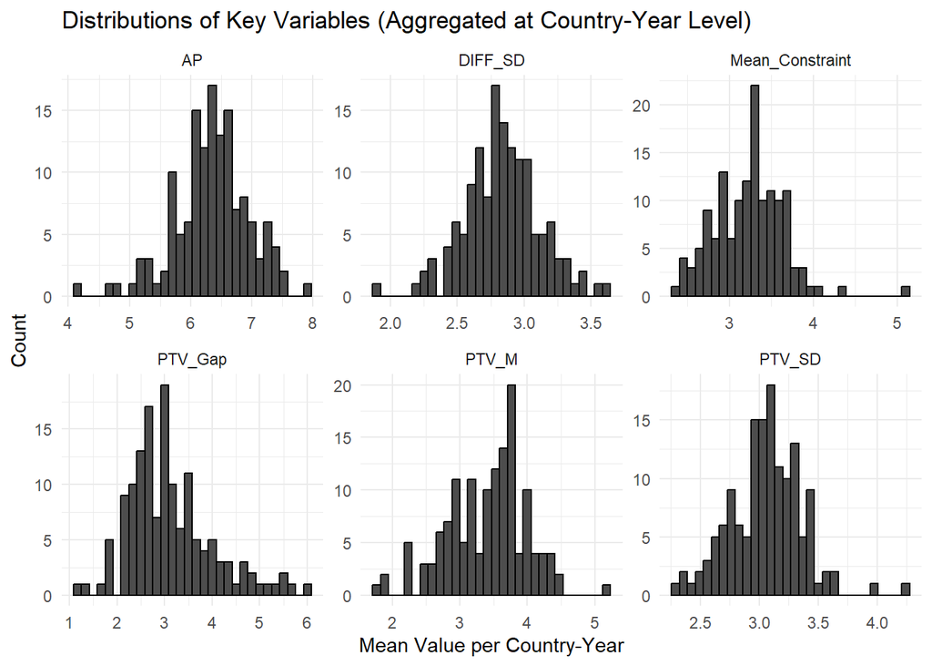

```r
# Aggregate data at the country-year level (taking the mean per country_year)
data_agg <- data %>%
  group_by(country_year) %>%
  summarize(across(c(Mean_Constraint, PTV_Gap, AP, DIFF_SD, PTV_SD, PTV_M), mean, na.rm = TRUE)) %>%
  pivot_longer(cols = -country_year, names_to = "Variable", values_to = "Value")

# Create histograms of country-year aggregated data
p <- ggplot(data_agg, aes(x = Value)) +
  geom_histogram(fill = "gray30", color = "black", bins = 30) +
  facet_wrap(~Variable, scales = "free") +
  theme_minimal() +
  labs(title = "Distributions of Key Variables (Aggregated at Country-Year Level)",
       x = "Mean Value per Country-Year",
       y = "Count")

# Print the plot
print(p)
```

```r
# Check variable types
#str(data)

# Check factors
table(data$vote, useNA = "always")
```

```
##
## No Vote    Vote    <NA>
##   24015   69011       0
```

```r
table(data$vote_choice, useNA = "always")
```

```
##
## No Vote    Vote    <NA>
##   30350   62676       0
```

```r
table(data$sex, useNA = "always")
```

```
##
##   Male Female   <NA>
##  46356  46670      0
```

```r
table(data$partisan, useNA = "always")
```

```
##
## Non-Partisan     Partisan         <NA>
##        24655        68371            0
```

```r
# General summary
#summary(data)
```

```r
# Function to rescale and center numeric variables within country_year
rescale_and_center <- function(data, var_name) {

  if (var_name %in% names(data) && is.numeric(data[[var_name]])) {

    # Rescale to 0-1
    data <- data %>%
      mutate(!!sym(var_name) := (get(var_name) - min(get(var_name), na.rm = TRUE)) /
                                 (max(get(var_name), na.rm = TRUE) - min(get(var_name), na.rm = TRUE)))

    # Center within country_year
    data <- data %>%
      group_by(country_year) %>%
      mutate(!!sym(paste0(var_name, "_centered")) := get(var_name) - mean(get(var_name), na.rm = TRUE)) %>%
      ungroup()

  } else {
    message(paste("Skipping:", var_name, "- Not a numeric variable"))
  }

  return(data)
}
```

```r
#Apply the function to all key PTV measures

data = rescale_and_center(data, "Mean_Constraint")
data = rescale_and_center(data, "PTV_Gap")
data = rescale_and_center(data, "AP")
data = rescale_and_center(data, "DIFF_SD")
data = rescale_and_center(data, "PTV_SD")
data = rescale_and_center(data, "PTV_M")

# Apply to individual level numeric controls
data = rescale_and_center(data, "pol_int")
data = rescale_and_center(data, "yb")
data = rescale_and_center(data, "class")

# Apply to country-level numeric controls
data = rescale_and_center(data, "ENEP")
data = rescale_and_center(data, "inflation")
```

## Models

### Baseline

I fit exploratory models where each re-scaled and centered PTV-derived variable predicts vote/no vote.

```r
# Ensure all models use the same data subset
data_1 <- data %>%
  select(vote,  country_year, Mean_Constraint_centered, PTV_Gap_centered, AP_centered, DIFF_SD_centered,
         PTV_SD_centered, PTV_M_centered) %>%
  na.omit()

# Fit a logistic multilevel model with random intercepts
m1 <- glmer(vote ~ Mean_Constraint_centered + (1 | country_year),
            data = data_1,
            family = binomial())

m2 <- glmer(vote ~ PTV_Gap_centered + (1 | country_year),
            data = data_1,
            family = binomial())

m3 <- glmer(vote ~ AP_centered + (1 | country_year),
            data = data_1,
            family = binomial())

m4 <- glmer(vote ~ DIFF_SD_centered + (1 | country_year),
            data = data_1,
            family = binomial())

m5 <- glmer(vote ~ PTV_SD_centered + (1 | country_year),
            data = data_1,
            family = binomial())

m6 <- glmer(vote ~ PTV_M_centered + (1 | country_year),
            data = data_1,
            family = binomial())

#list of models
m_list = list(m1, m2, m3, m4, m5, m6)

# sjPlot
tab_model(m_list, show.re.var = TRUE,
          show.icc = TRUE,
          show.aic = TRUE,
          dv.labels = "Predicting Vote (Multilevel Model)",
          title = "Logistic Multilevel Model Predicting Vote")
```

Logistic Multilevel Model Predicting Vote

|  | Predicting Vote (Multilevel Model) |  |  |  |  |  |  |  |  |  |  |  |  |  |  |  |  |  |
| --- | --- | --- | --- | --- | --- | --- | --- | --- | --- | --- | --- | --- | --- | --- | --- | --- | --- | --- |
| Predictors | Odds Ratios | CI | p | Odds Ratios | CI | p | Odds Ratios | CI | p | Odds Ratios | CI | p | Odds Ratios | CI | p | Odds Ratios | CI | p |
| (Intercept) | 7.97 | 5.43 – 11.71 | **<0.001** | 7.78 | 5.28 – 11.44 | **<0.001** | 8.01 | 5.43 – 11.82 | **<0.001** | 7.99 | 5.43 – 11.76 | **<0.001** | 8.01 | 5.44 – 11.80 | **<0.001** | 7.66 | 5.24 – 11.20 | **<0.001** |
| Mean Constraint centered | 12.03 | 10.96 – 13.19 | **<0.001** |  |  |  |  |  |  |  |  |  |  |  |  |  |  |  |
| PTV Gap centered |  |  |  | 2.57 | 2.43 – 2.73 | **<0.001** |  |  |  |  |  |  |  |  |  |  |  |  |
| AP centered |  |  |  |  |  |  | 6.84 | 6.40 – 7.31 | **<0.001** |  |  |  |  |  |  |  |  |  |
| DIFF SD centered |  |  |  |  |  |  |  |  |  | 8.30 | 7.67 – 8.97 | **<0.001** |  |  |  |  |  |  |
| PTV SD centered |  |  |  |  |  |  |  |  |  |  |  |  | 13.28 | 12.15 – 14.51 | **<0.001** |  |  |  |
| PTV M centered |  |  |  |  |  |  |  |  |  |  |  |  |  |  |  | 2.77 | 2.47 – 3.11 | **<0.001** |
| Random Effects |  |  |  |  |  |  |  |  |  |  |  |  |  |  |  |  |  |  |
| σ<sup>2</sup> | 3.29 |  |  | 3.29 |  |  | 3.29 |  |  | 3.29 |  |  | 3.29 |  |  | 3.29 |  |  |
| τ<sub>00</sub> | 5.32 <sub>country_year</sub> |  |  | 5.26 <sub>country_year</sub> |  |  | 5.33 <sub>country_year</sub> |  |  | 5.32 <sub>country_year</sub> |  |  | 5.33 <sub>country_year</sub> |  |  | 5.22 <sub>country_year</sub> |  |  |
| ICC | 0.62 |  |  | 0.62 |  |  | 0.62 |  |  | 0.62 |  |  | 0.62 |  |  | 0.61 |  |  |
| N | 143 <sub>country_year</sub> |  |  | 143 <sub>country_year</sub> |  |  | 143 <sub>country_year</sub> |  |  | 143 <sub>country_year</sub> |  |  | 143 <sub>country_year</sub> |  |  | 143 <sub>country_year</sub> |  |  |
| Observations | 93026 |  |  | 93026 |  |  | 93026 |  |  | 93026 |  |  | 93026 |  |  | 93026 |  |  |
| Marginal R<sup>2</sup> / Conditional R<sup>2</sup> | 0.020 / 0.625 |  |  | 0.008 / 0.618 |  |  | 0.023 / 0.627 |  |  | 0.021 / 0.626 |  |  | 0.023 / 0.627 |  |  | 0.002 / 0.614 |  |  |
| AIC | 90178.774 |  |  | 92029.820 |  |  | 89693.885 |  |  | 90075.534 |  |  | 89653.405 |  |  | 92750.938 |  |  |

The highest OR are for Mean constraint and PTV_SD.

### Individual level controls

```r
# Ensure all models use the same data subset
data_2 <- data %>%
  select(vote,  country_year, Mean_Constraint_centered, PTV_Gap_centered, AP_centered, DIFF_SD_centered,
         PTV_SD_centered, PTV_M_centered, pol_int_centered, partisan, sex, yb_centered, class_centered) %>%
  na.omit()

# Fit a logistic multilevel model with random intercepts
m1_2 <- glmer(vote ~ Mean_Constraint_centered +
            pol_int_centered + partisan + sex + yb_centered + class_centered +  # Individual-level
            + (1 | country_year),
            data = data_2,
            family = binomial())

m2_2 <- glmer(vote ~ PTV_Gap_centered +
            pol_int_centered + partisan + sex + yb_centered + class_centered +  # Individual-level
            + (1 | country_year),
            data = data_2,
            family = binomial())

m3_2 <- glmer(vote ~ AP_centered +
            pol_int_centered + partisan + sex + yb_centered + class_centered +  # Individual-level
            + (1 | country_year),
            data = data_2,
            family = binomial())

m4_2 <- glmer(vote ~ DIFF_SD_centered +
            pol_int_centered + partisan + sex + yb_centered + class_centered +  # Individual-level
            + (1 | country_year),
            data = data_2,
            family = binomial())

m5_2 <- glmer(vote ~ PTV_SD_centered +
            pol_int_centered + partisan + sex + yb_centered + class_centered +  # Individual-level
            + (1 | country_year),
            data = data_2,
            family = binomial())

m6_2 <- glmer(vote ~ PTV_M_centered +
            pol_int_centered + partisan + sex + yb_centered + class_centered +  # Individual-level
            + (1 | country_year),
            data = data_2,
            family = binomial())

#list of models
m2_list = list(m1_2, m2_2, m3_2, m4_2, m5_2, m6_2)

# sjPlot
tab_model(m2_list, show.re.var = TRUE,
          show.icc = TRUE,
          show.aic = TRUE,
          dv.labels = "Predicting Vote (Multilevel Model)",
          title = "Logistic Multilevel Model Predicting Vote, with individual level controls")
```

Logistic Multilevel Model Predicting Vote, with individual level controls

|  | Predicting Vote (Multilevel Model) |  |  |  |  |  |  |  |  |  |  |  |  |  |  |  |  |  |
| --- | --- | --- | --- | --- | --- | --- | --- | --- | --- | --- | --- | --- | --- | --- | --- | --- | --- | --- |
| Predictors | Odds Ratios | CI | p | Odds Ratios | CI | p | Odds Ratios | CI | p | Odds Ratios | CI | p | Odds Ratios | CI | p | Odds Ratios | CI | p |
| (Intercept) | 6.57 | 4.41 – 9.80 | **<0.001** | 6.06 | 4.07 – 9.03 | **<0.001** | 6.95 | 4.67 – 10.37 | **<0.001** | 6.70 | 4.50 – 9.98 | **<0.001** | 6.83 | 4.58 – 10.19 | **<0.001** | 5.73 | 3.84 – 8.54 | **<0.001** |
| Mean Constraint centered | 5.77 | 5.22 – 6.37 | **<0.001** |  |  |  |  |  |  |  |  |  |  |  |  |  |  |  |
| pol int centered | 5.48 | 5.15 – 5.84 | **<0.001** | 6.22 | 5.84 – 6.62 | **<0.001** | 5.66 | 5.31 – 6.03 | **<0.001** | 5.69 | 5.34 – 6.06 | **<0.001** | 5.48 | 5.14 – 5.84 | **<0.001** | 6.06 | 5.69 – 6.45 | **<0.001** |
| partisan [Partisan] | 1.43 | 1.37 – 1.49 | **<0.001** | 1.56 | 1.49 – 1.62 | **<0.001** | 1.33 | 1.27 – 1.39 | **<0.001** | 1.40 | 1.34 – 1.46 | **<0.001** | 1.37 | 1.31 – 1.43 | **<0.001** | 1.68 | 1.61 – 1.74 | **<0.001** |
| sex [Female] | 1.07 | 1.04 – 1.11 | **<0.001** | 1.10 | 1.06 – 1.14 | **<0.001** | 1.08 | 1.04 – 1.11 | **<0.001** | 1.07 | 1.04 – 1.11 | **<0.001** | 1.07 | 1.03 – 1.11 | **<0.001** | 1.09 | 1.06 – 1.13 | **<0.001** |
| yb centered | 0.13 | 0.11 – 0.14 | **<0.001** | 0.14 | 0.12 – 0.15 | **<0.001** | 0.15 | 0.13 – 0.17 | **<0.001** | 0.15 | 0.13 – 0.16 | **<0.001** | 0.14 | 0.12 – 0.15 | **<0.001** | 0.11 | 0.10 – 0.12 | **<0.001** |
| class centered | 1.79 | 1.66 – 1.93 | **<0.001** | 1.89 | 1.76 – 2.04 | **<0.001** | 1.87 | 1.74 – 2.02 | **<0.001** | 1.87 | 1.74 – 2.02 | **<0.001** | 1.83 | 1.69 – 1.97 | **<0.001** | 1.82 | 1.69 – 1.96 | **<0.001** |
| PTV Gap centered |  |  |  | 1.75 | 1.64 – 1.86 | **<0.001** |  |  |  |  |  |  |  |  |  |  |  |  |
| AP centered |  |  |  |  |  |  | 3.73 | 3.47 – 4.02 | **<0.001** |  |  |  |  |  |  |  |  |  |
| DIFF SD centered |  |  |  |  |  |  |  |  |  | 4.05 | 3.72 – 4.41 | **<0.001** |  |  |  |  |  |  |
| PTV SD centered |  |  |  |  |  |  |  |  |  |  |  |  | 6.02 | 5.47 – 6.63 | **<0.001** |  |  |  |
| PTV M centered |  |  |  |  |  |  |  |  |  |  |  |  |  |  |  | 3.14 | 2.78 – 3.55 | **<0.001** |
| Random Effects |  |  |  |  |  |  |  |  |  |  |  |  |  |  |  |  |  |  |
| σ<sup>2</sup> | 3.29 |  |  | 3.29 |  |  | 3.29 |  |  | 3.29 |  |  | 3.29 |  |  | 3.29 |  |  |
| τ<sub>00</sub> | 5.59 <sub>country_year</sub> |  |  | 5.57 <sub>country_year</sub> |  |  | 5.60 <sub>country_year</sub> |  |  | 5.59 <sub>country_year</sub> |  |  | 5.60 <sub>country_year</sub> |  |  | 5.56 <sub>country_year</sub> |  |  |
| ICC | 0.63 |  |  | 0.63 |  |  | 0.63 |  |  | 0.63 |  |  | 0.63 |  |  | 0.63 |  |  |
| N | 143 <sub>country_year</sub> |  |  | 143 <sub>country_year</sub> |  |  | 143 <sub>country_year</sub> |  |  | 143 <sub>country_year</sub> |  |  | 143 <sub>country_year</sub> |  |  | 143 <sub>country_year</sub> |  |  |
| Observations | 93026 |  |  | 93026 |  |  | 93026 |  |  | 93026 |  |  | 93026 |  |  | 93026 |  |  |
| Marginal R<sup>2</sup> / Conditional R<sup>2</sup> | 0.067 / 0.654 |  |  | 0.062 / 0.652 |  |  | 0.068 / 0.655 |  |  | 0.067 / 0.654 |  |  | 0.068 / 0.655 |  |  | 0.061 / 0.651 |  |  |
| AIC | 84120.992 |  |  | 85027.854 |  |  | 84075.912 |  |  | 84262.726 |  |  | 83983.389 |  |  | 84983.727 |  |  |

All models converged without warnings. Note that I rescaled and centered all variables but the factors (partisan and sex, both dummies).

The highest OR remain those of Mean constraint and PTV_SD.

### Country level controls

```r
# Ensure all models use the same data subset
data_3 <- data %>%
  select(vote, country_year,
         Mean_Constraint_centered, PTV_Gap_centered, AP_centered, DIFF_SD_centered,
         PTV_SD_centered, PTV_M_centered,
         pol_int_centered, partisan, sex, yb_centered, class_centered,  # Individual-level
         ENEP_centered, inflation_centered, mand) %>%  # Country-level
  na.omit()

# Fit a logistic multilevel model with random intercepts (Baseline with Constraint)
m1_3 <- glmer(vote ~ Mean_Constraint_centered +
            pol_int_centered + partisan + sex + yb_centered + class_centered +  # Individual-level
            ENEP_centered + inflation_centered + mand +                        # Country-level
            (1 | country_year),
            data = data_3,
            family = binomial())

# PTV Gap Model
m2_3 <- glmer(vote ~ PTV_Gap_centered +
            pol_int_centered + partisan + sex + yb_centered + class_centered +  # Individual-level
            ENEP_centered + inflation_centered + mand +                        # Country-level
            (1 | country_year),
            data = data_3,
            family = binomial())

# Affective Polarization (AP) Model
m3_3 <- glmer(vote ~ AP_centered +
            pol_int_centered + partisan + sex + yb_centered + class_centered +  # Individual-level
            ENEP_centered + inflation_centered + mand +                        # Country-level
            (1 | country_year),
            data = data_3,
            family = binomial())

# DIFF_SD Model (Variance in Differences)
m4_3 <- glmer(vote ~ DIFF_SD_centered +
            pol_int_centered + partisan + sex + yb_centered + class_centered +  # Individual-level
            ENEP_centered + inflation_centered + mand +                        # Country-level
            (1 | country_year),
            data = data_3,
            family = binomial())

# PTV_SD Model (Variance in PTVs)
m5_3 <- glmer(vote ~ PTV_SD_centered +
            pol_int_centered + partisan + sex + yb_centered + class_centered +  # Individual-level
            ENEP_centered + inflation_centered + mand +                        # Country-level
            (1 | country_year),
            data = data_3,
            family = binomial())

# PTV_M Model (Mean PTV Score)
m6_3 <- glmer(vote ~ PTV_M_centered +
            pol_int_centered + partisan + sex + yb_centered + class_centered +  # Individual-level
            ENEP_centered + inflation_centered + mand +                        # Country-level
            (1 | country_year),
            data = data_3,
            family = binomial())

# List of models
m3_list = list(m1_3, m2_3, m3_3, m4_3, m5_3, m6_3)

# sjPlot
tab_model(m3_list, show.re.var = TRUE,
          show.icc = TRUE,
          show.aic = TRUE,
          dv.labels = "Predicting Vote (Multilevel Model, Full Controls)",
          title = "Logistic Multilevel Model Predicting Vote, with individual and country-level controls")
```

Logistic Multilevel Model Predicting Vote, with individual and country-level controls

|  | Predicting Vote (Multilevel Model, Full Controls) |  |  |  |  |  |  |  |  |  |  |  |  |  |  |  |  |  |
| --- | --- | --- | --- | --- | --- | --- | --- | --- | --- | --- | --- | --- | --- | --- | --- | --- | --- | --- |
| Predictors | Odds Ratios | CI | p | Odds Ratios | CI | p | Odds Ratios | CI | p | Odds Ratios | CI | p | Odds Ratios | CI | p | Odds Ratios | CI | p |
| (Intercept) | 4.45 | 2.97 – 6.69 | **<0.001** | 4.12 | 2.74 – 6.19 | **<0.001** | 4.71 | 3.13 – 7.07 | **<0.001** | 4.54 | 3.02 – 6.83 | **<0.001** | 4.62 | 3.07 – 6.95 | **<0.001** | 3.90 | 2.59 – 5.86 | **<0.001** |
| Mean Constraint centered | 5.89 | 5.33 – 6.51 | **<0.001** |  |  |  |  |  |  |  |  |  |  |  |  |  |  |  |
| pol int centered | 5.43 | 5.09 – 5.78 | **<0.001** | 6.18 | 5.80 – 6.59 | **<0.001** | 5.61 | 5.26 – 5.98 | **<0.001** | 5.64 | 5.29 – 6.01 | **<0.001** | 5.43 | 5.09 – 5.78 | **<0.001** | 6.01 | 5.65 – 6.41 | **<0.001** |
| partisan [Partisan] | 1.43 | 1.38 – 1.50 | **<0.001** | 1.56 | 1.50 – 1.62 | **<0.001** | 1.33 | 1.27 – 1.39 | **<0.001** | 1.40 | 1.34 – 1.46 | **<0.001** | 1.37 | 1.31 – 1.43 | **<0.001** | 1.68 | 1.61 – 1.75 | **<0.001** |
| sex [Female] | 1.07 | 1.03 – 1.11 | **<0.001** | 1.10 | 1.06 – 1.13 | **<0.001** | 1.07 | 1.04 – 1.11 | **<0.001** | 1.07 | 1.04 – 1.11 | **<0.001** | 1.07 | 1.03 – 1.10 | **<0.001** | 1.09 | 1.05 – 1.13 | **<0.001** |
| yb centered | 0.13 | 0.11 – 0.14 | **<0.001** | 0.14 | 0.12 – 0.15 | **<0.001** | 0.15 | 0.14 – 0.17 | **<0.001** | 0.15 | 0.13 – 0.17 | **<0.001** | 0.14 | 0.13 – 0.16 | **<0.001** | 0.11 | 0.10 – 0.12 | **<0.001** |
| class centered | 1.80 | 1.67 – 1.94 | **<0.001** | 1.90 | 1.77 – 2.05 | **<0.001** | 1.88 | 1.75 – 2.03 | **<0.001** | 1.88 | 1.75 – 2.03 | **<0.001** | 1.84 | 1.70 – 1.98 | **<0.001** | 1.82 | 1.69 – 1.97 | **<0.001** |
| mand [Yes] | 5.43 | 2.03 – 14.52 | **0.001** | 5.34 | 1.99 – 14.29 | **0.001** | 5.46 | 2.04 – 14.56 | **0.001** | 5.43 | 2.03 – 14.52 | **0.001** | 5.47 | 2.03 – 14.68 | **0.001** | 5.30 | 1.98 – 14.18 | **0.001** |
| PTV Gap centered |  |  |  | 1.75 | 1.64 – 1.86 | **<0.001** |  |  |  |  |  |  |  |  |  |  |  |  |
| AP centered |  |  |  |  |  |  | 3.78 | 3.51 – 4.07 | **<0.001** |  |  |  |  |  |  |  |  |  |
| DIFF SD centered |  |  |  |  |  |  |  |  |  | 4.11 | 3.77 – 4.48 | **<0.001** |  |  |  |  |  |  |
| PTV SD centered |  |  |  |  |  |  |  |  |  |  |  |  | 6.13 | 5.56 – 6.76 | **<0.001** |  |  |  |
| PTV M centered |  |  |  |  |  |  |  |  |  |  |  |  |  |  |  | 3.16 | 2.79 – 3.57 | **<0.001** |
| Random Effects |  |  |  |  |  |  |  |  |  |  |  |  |  |  |  |  |  |  |
| σ<sup>2</sup> | 3.29 |  |  | 3.29 |  |  | 3.29 |  |  | 3.29 |  |  | 3.29 |  |  | 3.29 |  |  |
| τ<sub>00</sub> | 4.65 <sub>country_year</sub> |  |  | 4.65 <sub>country_year</sub> |  |  | 4.66 <sub>country_year</sub> |  |  | 4.66 <sub>country_year</sub> |  |  | 4.66 <sub>country_year</sub> |  |  | 4.64 <sub>country_year</sub> |  |  |
| ICC | 0.59 |  |  | 0.59 |  |  | 0.59 |  |  | 0.59 |  |  | 0.59 |  |  | 0.59 |  |  |
| N | 137 <sub>country_year</sub> |  |  | 137 <sub>country_year</sub> |  |  | 137 <sub>country_year</sub> |  |  | 137 <sub>country_year</sub> |  |  | 137 <sub>country_year</sub> |  |  | 137 <sub>country_year</sub> |  |  |
| Observations | 88261 |  |  | 88261 |  |  | 88261 |  |  | 88261 |  |  | 88261 |  |  | 88261 |  |  |
| Marginal R<sup>2</sup> / Conditional R<sup>2</sup> | 0.113 / 0.633 |  |  | 0.107 / 0.630 |  |  | 0.114 / 0.633 |  |  | 0.113 / 0.633 |  |  | 0.114 / 0.633 |  |  | 0.106 / 0.629 |  |  |
| AIC | 81946.692 |  |  | 82860.041 |  |  | 81909.219 |  |  | 82089.823 |  |  | 81811.713 |  |  | 82815.131 |  |  |

Again, no warnings!

Main result is that the OR of Mean constraint and PTV_SD remain significant and very high. These OR are comparable to those of country-level variables (e.g.: mand [mandatory voting]) and individual level ones (pol interest)

### Comparison between measures

I now test if Constraint or PTV_SD are better than AP

```r
# Compare full models using AIC/BIC
model_comparison <- data.frame(
  Model = c("Full Model (Mean Constraint)",
            "Full Model (Affective Polarization)",
            "Full Model (PTV_SD)"),
  AIC = c(AIC(m1_3), AIC(m3_3), AIC(m5_3)),
  BIC = c(BIC(m1_3), BIC(m3_3), BIC(m5_3)),
  LogLikelihood = c(logLik(m1_3), logLik(m3_3), logLik(m5_3))
)

print(model_comparison)
```

```
##                                 Model      AIC      BIC LogLikelihood
## 1        Full Model (Mean Constraint) 81946.69 82031.18     -40964.35
## 2 Full Model (Affective Polarization) 81909.22 81993.71     -40945.61
## 3                 Full Model (PTV_SD) 81811.71 81896.21     -40896.86
```

Best is PTV_SD, then AP, then Constraint. Now the formal test:

```r
# Likelihood Ratio Tests
anova(m3_3, m1_3, test = "Chisq")  # Mean Constraint vs. Affective Polarization
```

```
## Data: data_3
## Models:
## m3_3: vote ~ AP_centered + pol_int_centered + partisan + sex + yb_centered + class_centered + ENEP_centered + inflation_centered + mand + (1 | country_year)
## m1_3: vote ~ Mean_Constraint_centered + pol_int_centered + partisan + sex + yb_centered + class_centered + ENEP_centered + inflation_centered + mand + (1 | country_year)
##      npar   AIC   BIC logLik deviance Chisq Df Pr(>Chisq)
## m3_3    9 81909 81994 -40946    81891
## m1_3    9 81947 82031 -40964    81929     0  0
```

```r
anova(m3_3, m5_3, test = "Chisq")  # PTV_SD vs. Affective Polarization
```

```
## Data: data_3
## Models:
## m3_3: vote ~ AP_centered + pol_int_centered + partisan + sex + yb_centered + class_centered + ENEP_centered + inflation_centered + mand + (1 | country_year)
## m5_3: vote ~ PTV_SD_centered + pol_int_centered + partisan + sex + yb_centered + class_centered + ENEP_centered + inflation_centered + mand + (1 | country_year)
##      npar   AIC   BIC logLik deviance  Chisq Df Pr(>Chisq)
## m3_3    9 81909 81994 -40946    81891
## m5_3    9 81812 81896 -40897    81794 97.506  0
```

Results are confirmed. We should work with the SD of PTV scores directly I guess. But the gap between AP and constraint is very tiny.

### Interactions

#### with PTV_M

I specify an individual level interaction between mean constraint and PTV_M. This would tell us if the role of constraint varies across mean levels of PTV scores. I do the same interaction also for the other best predictors we have found: PTV_SD.

```r
# Mean Constraint Model with Interaction
m1_3_interaction <- glmer(vote ~ Mean_Constraint_centered * PTV_M_centered +  # Interaction term
            pol_int_centered + partisan + sex + yb_centered + class_centered +  # Individual-level
            ENEP_centered + inflation_centered + mand +                        # Country-level
            (1 | country_year),
            data = data_3,
            family = binomial())

# PTV_SD Model with Interaction
m5_3_interaction <- glmer(vote ~ PTV_SD_centered * PTV_M_centered +  # Interaction term
            pol_int_centered + partisan + sex + yb_centered + class_centered +  # Individual-level
            ENEP_centered + inflation_centered + mand +                        # Country-level
            (1 | country_year),
            data = data_3,
            family = binomial())

# List of interaction models
m3_list_interaction <- list(m1_3_interaction, m5_3_interaction)

# sjPlot: Displaying the results in a neat table
tab_model(m3_list_interaction, show.re.var = TRUE,
          show.icc = TRUE,
          show.aic = TRUE,
          dv.labels = "Predicting Vote (Multilevel Model, Interaction Included)",
          title = "Logistic Multilevel Model Predicting Vote with Interaction (Constraint × PTV Mean)")
```

Logistic Multilevel Model Predicting Vote with Interaction (Constraint × PTV Mean)

|  | Predicting Vote (Multilevel Model, Interaction Included) |  |  |  |  |  |
| --- | --- | --- | --- | --- | --- | --- |
| Predictors | Odds Ratios | CI | p | Odds Ratios | CI | p |
| (Intercept) | 4.61 | 3.07 – 6.93 | **<0.001** | 4.69 | 3.12 – 7.04 | **<0.001** |
| Mean Constraint centered | 5.48 | 4.93 – 6.09 | **<0.001** |  |  |  |
| PTV M centered | 1.01 | 0.87 – 1.17 | 0.866 | 1.76 | 1.53 – 2.03 | **<0.001** |
| pol int centered | 5.33 | 5.00 – 5.68 | **<0.001** | 5.32 | 4.99 – 5.67 | **<0.001** |
| partisan [Partisan] | 1.41 | 1.36 – 1.47 | **<0.001** | 1.35 | 1.29 – 1.41 | **<0.001** |
| sex [Female] | 1.07 | 1.03 – 1.10 | **<0.001** | 1.06 | 1.02 – 1.10 | **0.001** |
| yb centered | 0.12 | 0.11 – 0.13 | **<0.001** | 0.13 | 0.11 – 0.14 | **<0.001** |
| class centered | 1.78 | 1.65 – 1.92 | **<0.001** | 1.81 | 1.68 – 1.95 | **<0.001** |
| mand [Yes] | 5.53 | 2.06 – 14.83 | **0.001** | 5.57 | 2.09 – 14.81 | **0.001** |
| Mean Constraint centered × PTV M centered | 0.02 | 0.01 – 0.03 | **<0.001** |  |  |  |
| PTV SD centered |  |  |  | 5.45 | 4.94 – 6.03 | **<0.001** |
| PTV SD centered × PTV M centered |  |  |  | 0.06 | 0.04 – 0.10 | **<0.001** |
| Random Effects |  |  |  |  |  |  |
| σ<sup>2</sup> | 3.29 |  |  | 3.29 |  |  |
| τ<sub>00</sub> | 4.64 <sub>country_year</sub> |  |  | 4.66 <sub>country_year</sub> |  |  |
| ICC | 0.59 |  |  | 0.59 |  |  |
| N | 137 <sub>country_year</sub> |  |  | 137 <sub>country_year</sub> |  |  |
| Observations | 88261 |  |  | 88261 |  |  |
| Marginal R<sup>2</sup> / Conditional R<sup>2</sup> | 0.116 / 0.633 |  |  | 0.117 / 0.635 |  |  |
| AIC | 81667.124 |  |  | 81475.746 |  |  |

The effect of constraint on voting is reduced when PTV Mean is high. So when individuals like fewer parties (lower PTV_M), constraint plays a stronger role in motivating turnout.

In the same vein, the effect of PTV_SD (variance in PTV scores) on voting is weaker for those with higher PTV_M.

#### with Partisanship

I fit the same models, but interacting with Partisanship (dummy). I think this might be cleaner cause the measure are more independent (cause partisanship is not built from PTV).

```r
# Mean Constraint Model with Interaction (Mean Constraint × Partisanship)
m1_4_interaction <- glmer(vote ~ Mean_Constraint_centered * partisan +  # Interaction term
            pol_int_centered + sex + yb_centered + class_centered +  # Individual-level
            ENEP_centered + inflation_centered + mand +              # Country-level
            (1 | country_year),
            data = data_3,
            family = binomial())

# PTV_SD Model with Interaction (PTV_SD × Partisanship)
m5_4_interaction <- glmer(vote ~ PTV_SD_centered * partisan +  # Interaction term
            pol_int_centered + sex + yb_centered + class_centered +  # Individual-level
            ENEP_centered + inflation_centered + mand +              # Country-level
            (1 | country_year),
            data = data_3,
            family = binomial())

# List of interaction models
m4_list_interaction <- list(m1_4_interaction, m5_4_interaction)

# sjPlot: Displaying the results in a neat table
tab_model(m4_list_interaction, show.re.var = TRUE,
          show.icc = TRUE,
          show.aic = TRUE,
          dv.labels = "Predicting Vote (Multilevel Model, Interaction Included)",
          title = "Logistic Multilevel Model Predicting Vote with Interaction (Constraint × Partisanship)")
```

Logistic Multilevel Model Predicting Vote with Interaction (Constraint × Partisanship)

|  | Predicting Vote (Multilevel Model, Interaction Included) |  |  |  |  |  |
| --- | --- | --- | --- | --- | --- | --- |
| Predictors | Odds Ratios | CI | p | Odds Ratios | CI | p |
| (Intercept) | 4.53 | 3.01 – 6.82 | **<0.001** | 4.69 | 3.12 – 7.04 | **<0.001** |
| Mean Constraint centered | 7.54 | 6.44 – 8.84 | **<0.001** |  |  |  |
| partisan [Partisan] | 1.41 | 1.35 – 1.47 | **<0.001** | 1.35 | 1.29 – 1.41 | **<0.001** |
| pol int centered | 5.43 | 5.10 – 5.79 | **<0.001** | 5.43 | 5.10 – 5.79 | **<0.001** |
| sex [Female] | 1.07 | 1.03 – 1.11 | **<0.001** | 1.07 | 1.03 – 1.10 | **<0.001** |
| yb centered | 0.13 | 0.11 – 0.14 | **<0.001** | 0.14 | 0.13 – 0.16 | **<0.001** |
| class centered | 1.80 | 1.67 – 1.94 | **<0.001** | 1.84 | 1.70 – 1.98 | **<0.001** |
| mand [Yes] | 5.44 | 2.03 – 14.62 | **0.001** | 5.47 | 2.05 – 14.64 | **0.001** |
| Mean Constraint centered × partisan [Partisan] | 0.66 | 0.54 – 0.81 | **<0.001** |  |  |  |
| PTV SD centered |  |  |  | 7.25 | 6.22 – 8.45 | **<0.001** |
| PTV SD centered × partisan [Partisan] |  |  |  | 0.75 | 0.62 – 0.92 | **0.005** |
| Random Effects |  |  |  |  |  |  |
| σ<sup>2</sup> | 3.29 |  |  | 3.29 |  |  |
| τ<sub>00</sub> | 4.64 <sub>country_year</sub> |  |  | 4.65 <sub>country_year</sub> |  |  |
| ICC | 0.59 |  |  | 0.59 |  |  |
| N | 137 <sub>country_year</sub> |  |  | 137 <sub>country_year</sub> |  |  |
| Observations | 88261 |  |  | 88261 |  |  |
| Marginal R<sup>2</sup> / Conditional R<sup>2</sup> | 0.113 / 0.632 |  |  | 0.114 / 0.633 |  |  |
| AIC | 81932.684 |  |  | 81805.869 |  |  |

The effect of Constraint on voting is weaker for partisans. So higher constraint boosts turnout more among non-partisans. Same thing for the interaction between PTV_SD and partisanship. Greater differentiation in party evaluations increases turnout more for non-partisans.